# Part II - PISA 2012 Explanation

## by Jamie Potter

## Investigation Overview

This investigation concerned the 2012 PISA data, finding patterns associated with student test scores in Mathematics, Reading and Science. Key insights:

1. Possessions are an indicator of household wealth. In general, the more possessions you have, the wealthier you are, and the higher your score in the PISA test.

2. Books aren't special. The number of books in your household has no discernible effect specifically on reading beyond being a general indicator of wealth.

3. Household wealth interacts with parental education levels. At higher wealth levels, pupils with parents having the highest education levels scored the best. At lower wealth levels, pupils with the highest average test scores come from households where the highest parental education levels are secondary/vocational.

4. Males tend to have slightly higher mathematics scores than females, but females have higher reading scores than males.

5. Sex interacts with wealth, especially for reading scores. As wealth level increases, female reading scores improve faster than male scores.

## Dataset Overview

The data are from the 2012 round of the Programme for International Student Assessment (PISA), a triennial international education survey organised by the Organisation for Economic Co-operation and Development (OECD). The aim is to provide meaningful international comparisons for the educational attainment of 15-16 year olds for participant nations.

Alongside a general questionnaire that quizzed pupils on various aspects of school life and life at home, pupils take a two hour computer-based test. Scores are then scaled so that the average in each of the three areas tested (mathematics, reading, science) have mean 500, standard deviation 100. Typically, the object of most media interest is the ranking that appears at the end, where countries are ranked in terms of their mean scores. The 2012 survey also included a section on problem-solving.

The dataset was downloaded on 06/11/2021 from Udacity's server [here](https://s3.amazonaws.com/udacity-hosted-downloads/ud507/pisa2012.csv.zip).

## 1. Possessions and Student Scores

PISA includes multiple data from survey questions asking about possessions in the student's household. The below plot shows that the mean overall score (i.e. the average of a student's Mathematics, Reading and Science score) increases with the number of possessions in the household. (Black bars indicate the standard deviations of the overall score).

Possessions seem to be a good indicator of underlying wealth, which in turn is associated with higher student scores.

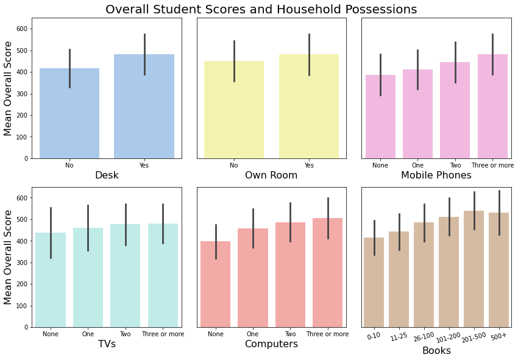

## 2. Books Aren't Special

You'd be forgiven for thinking that this pattern (possessions indicate wealth, and higher wealth is associated with higher test scores) things might be different specifically books. The number of books must surely have more of an effect on Reading? If we break out the overall scores into Mathematics, Reading and Science, however, the violin plot below shows otherwise. (Dashed, horizontal lines indicate the first quartile, median, and third quartile).

The number of books is like any other possession - students coming from households with more possessions tend to have higher scores in all three test metrics. It seems that overall wealth, not the type of possessions one owns, is what matters.

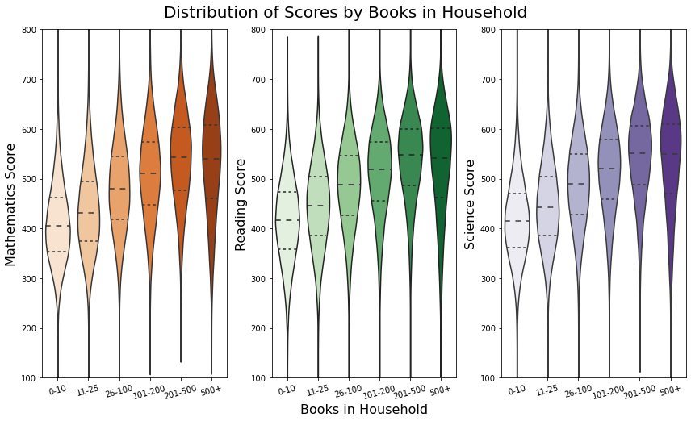

## 3. The Interaction of Wealth and Parental Education

PISA scores aren't all about wealth, though. The highest education level achieved by the students' parents matters too, and interacts with wealth. In the heat map below, darker squares indicate higher average scores for students in that category.

Wealth and highest parental education level are both associated with higher average test scores. However, when it comes to lower wealth levels, the pupils with the highest average test scores tended to come from households where the highest parental education levels are secondary/vocational.

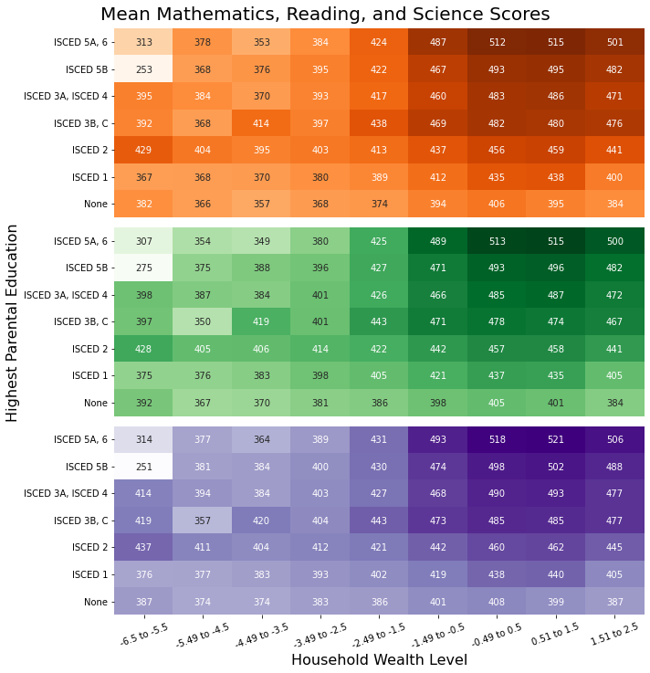

## 4. Sex

Looking at the distributions of student scores in the three tests, Mathematics, Reading and Science, we see that sex makes little difference in the case of science, but perhaps males have a slight advantage in Mathematics. There is a larger gap in the opposite direction, however, in Reading.

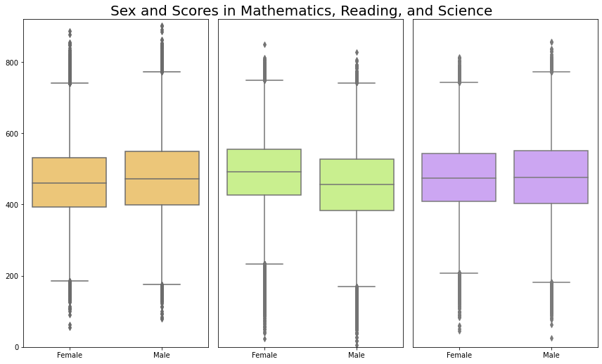

## 5. The Interaction of Wealth and Sex

The interesting thing about reading scores is that wealth seems to be a factor. As wealth increases, student scores increase. However, female scores in Mathematics and Science increase 13% faster than they do for males. What's really interesting, though, is that they increase 22% faster when it comes to reading. This can be seen in the scattergraph below, with the regression line for females being noticeably steeper than for males.

For some reason, increasing wealth has more of an impact on females than it does males, and this effect is most pronounced when it comes to reading scores.

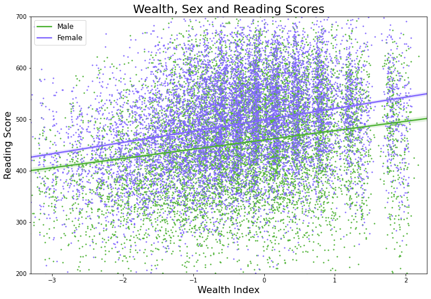